# Practical Machine Learning - Course Project

Evan Falcone

## Introduction

### Background

Using devices such as Jawbone Up, Nike FuelBand, and Fitbit it is now possible to collect a large amount of data about personal activity relatively inexpensively. These type of devices are part of the quantified self movement - a group of enthusiasts who take measurements about themselves regularly to improve their health, to find patterns in their behavior, or because they are tech geeks. One thing that people regularly do is quantify how much of a particular activity they do, but they rarely quantify how well they do it. In this project, your goal will be to use data from accelerometers on the belt, forearm, arm, and dumbell of 6 participants. They were asked to perform barbell lifts correctly and incorrectly in 5 different ways. More information is available from the website [here (see the section on the Weight Lifting Exercise Dataset).](http://groupware.les.inf.puc-rio.br/har)

### Data

The training data for this project are available [here.](https://d396qusza40orc.cloudfront.net/predmachlearn/pml-training.csv)

The test data are available [here.](https://d396qusza40orc.cloudfront.net/predmachlearn/pml-testing.csv)

The data for this project come from [this source.](http://groupware.les.inf.puc-rio.br/har%3E) If you use the document you create for this class for any purpose please cite them as they have been very generous in allowing their data to be used for this kind of assignment.

## Getting and Loading the Data

```r
library(caret)
```

```r
library(rpart)
library(rpart.plot)
library(RColorBrewer)
library(rattle)
library(randomForest)
library(knitr)

# set.seed(12345) # test seed, compare to bookmark
set.seed(12345)

trainUrl <- "http://d396qusza40orc.cloudfront.net/predmachlearn/pml-training.csv"
testUrl <- "http://d396qusza40orc.cloudfront.net/predmachlearn/pml-testing.csv"

training <- read.csv(url(trainUrl), na.strings=c("NA","#DIV/0!",""))
testing <- read.csv(url(testUrl), na.strings=c("NA","#DIV/0!",""))
```

#### Partition the test and training sets using the caret package createDataPartition function:

```r
inTrain <- createDataPartition(training$classe, p=0.6, list=FALSE)
myTraining <- training[inTrain, ]
myTesting <- training[-inTrain, ]
# print the dimensions of myTraining and myTesting for exploratory purposes:
dim(myTraining); dim(myTesting)
```

```
## [1] 11776   160
```

```
## [1] 7846  160
```

## Data Cleaning/Prep

#### Remove Near-Zero variance variables:

```r
nzv <- nearZeroVar(myTraining, saveMetrics=TRUE)
myTraining <- myTraining[,nzv$nzv==FALSE]

nzv<- nearZeroVar(myTesting,saveMetrics=TRUE)
myTesting <- myTesting[,nzv$nzv==FALSE]

rm(nzv)
```

#### Remove columns with more than 80% entries as NAs:

```r
# Here we get the indexes of the columns having at least 80% of NA or blank values on the training dataset
indColToRemove <- which(colSums(is.na(myTraining) | myTraining == "") > 0.8 * dim(myTraining)[1])
# Remove the columns with 80% NAs
trainNa <- myTraining[,-indColToRemove]
# Remove the first seven columns (timestampes, unused in our analysis)
trainNa <- trainNa[,-c(1:7)]
dim(trainNa)
```

```
## [1] 11776    52
```

```r
# Here we get the indexes of the columns having at least 80% of NA or blank values on the testing dataset
indColToRemove <- which(colSums(is.na(myTesting) | myTesting == "") > 0.8 * dim(myTesting)[1])
# Remove the columns with 80% NAs
testNa <- myTesting[,-indColToRemove]
# Remove the first column from test (unused in our analysis)
testNa <- testNa[,-1]
dim(testNa)
```

```
## [1] 7846   58
```

```r
inTrainNew <- createDataPartition(trainNa$classe, p=0.75, list=FALSE)
trainNew <- trainNa[inTrainNew,]
testNew <- trainNa[-inTrainNew,]
dim(trainNew)
```

```
## [1] 8834   52
```

```r
dim(testNew)
```

```
## [1] 2942   52
```

In the following sections, we will test 3 different models:

1. Classification Tree
2. Random Forest
3. Gradient Boosted Method

In order to limit the effects of overfitting, and improve the efficicency of the models, we will use cross-validation: we will use 5 folds (usually, 5 or 10 can be used, but 10 folds gives higher run times with no significant increase of the accuracy).

## Classification Trees model

#### Train with classification tree

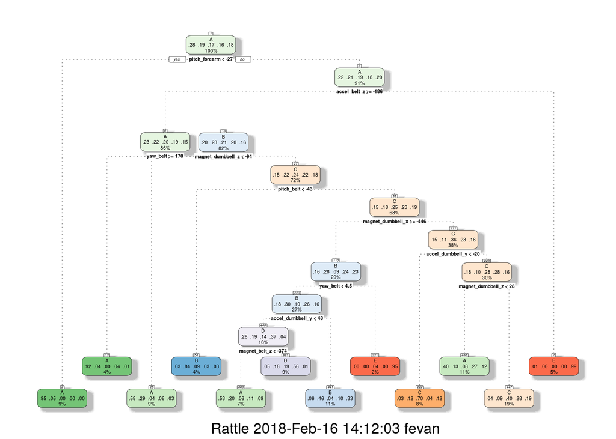

```r
trControl <- trainControl(method="cv", number=5)
model_CT <- train(classe~., data=trainNew, method="rpart", trControl=trControl)

# Print your model_CT:
fancyRpartPlot(model_CT$finalModel)
```

```r
# Predict using the model from trainNew on testNew & create the Confusion Matrix:
trainPred <- predict(model_CT,newdata=testNew)
confMatCT <- confusionMatrix(testNew$classe,trainPred)

# Display confusion matrix:
confMatCT$table
```

```
##           Reference
## Prediction   A   B   C   D   E
##          A 770  10  37  16   4
##          B 175 273  75  46   0
##          C  51  24 372  58   8
##          D 136  36 159 151   0
##          E  72 111 121   2 235
```

```r
# Display model accuracy:
confMatCT$overall[1]
```

```
##  Accuracy
## 0.6121686
```

## Random Forests model

#### Train with Random Forests

```r
model_RF <- train(classe~., data=trainNew, method="rf", trControl=trControl, verbose=FALSE)

# Print your model_RF:
print(model_RF)
```

```
## Random Forest
##
## 8834 samples
##   51 predictors
##    5 classes: 'A', 'B', 'C', 'D', 'E'
##
## No pre-processing
## Resampling: Cross-Validated (5 fold)
## Summary of sample sizes: 7068, 7067, 7067, 7066, 7068
## Resampling results across tuning parameters:
##
##   mtry  Accuracy   Kappa
##    2    0.9801904  0.9749366
##   26    0.9826806  0.9780888
##   51    0.9770211  0.9709276
##
## Accuracy was used to select the optimal model using  the largest value.
## The final value used for the model was mtry = 26.
```

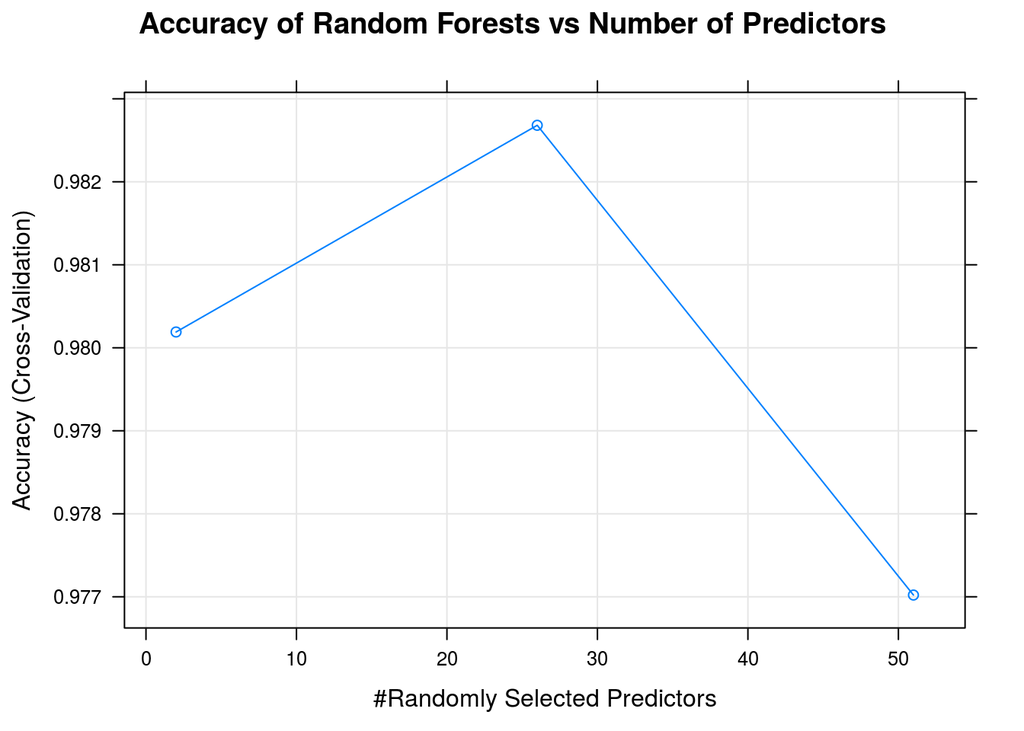

```r
# Plot your model_RF:
plot(model_RF, main = "Accuracy of Random Forests vs Number of Predictors")
```

```r
# Predict using the model from trainNew on testNew & create the Confusion Matrix:
trainPred <- predict(model_RF,newdata=testNew)
confMatRF <- confusionMatrix(testNew$classe,trainPred)

# Display confusion matrix:
confMatRF$table
```

```
##           Reference
## Prediction   A   B   C   D   E
##          A 837   0   0   0   0
##          B   5 562   2   0   0
##          C   0   0 511   2   0
##          D   0   0   9 473   0
##          E   0   0   2   2 537
```

```r
# Display model accuracy:
confMatRF$overall[1]
```

```
##  Accuracy
## 0.9925221
```

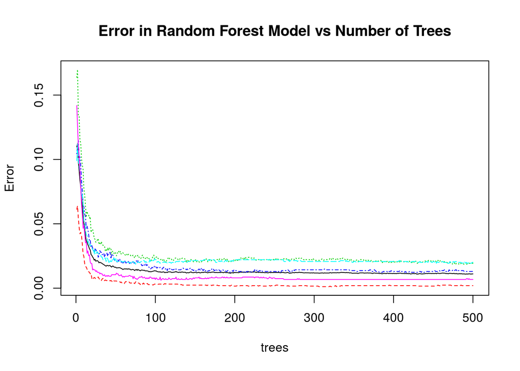

```r
# Plot the Random Forest
plot(model_RF$finalModel, main = "Error in Random Forest Model vs Number of Trees")
```

```r
# Display variable importance:
(MostImpVars <- varImp(model_RF))
```

```
## rf variable importance
##
##   only 20 most important variables shown (out of 51)
##
##                      Overall
## yaw_belt              100.00
## pitch_forearm          87.77
## pitch_belt             69.29
## magnet_dumbbell_z      65.55
## magnet_dumbbell_y      51.89
## roll_forearm           46.77
## accel_belt_z           43.27
## magnet_belt_z          29.81
## magnet_belt_y          29.14
## magnet_dumbbell_x      28.90
## roll_dumbbell          27.97
## accel_dumbbell_y       27.09
## gyros_belt_z           26.68
## accel_forearm_x        23.87
## accel_dumbbell_z       19.94
## magnet_belt_x          17.51
## magnet_forearm_z       16.84
## total_accel_dumbbell   16.08
## yaw_arm                14.16
## roll_arm               13.84
```

```r
# MostImpVars
```

The accuracy of the Random Forests model is very high (~99%) using 5-fold cross-validation. This implies that the outcome will be very well predicted by the predictors.

## Gradient Boosting model

#### Train with Gradient Boosting

```r
model_GBM <- train(classe~., data=trainNew, method="gbm", trControl=trControl, verbose=FALSE)
# Print your model_RF:
print(model_GBM)
```

```
## Stochastic Gradient Boosting
##
## 8834 samples
##   51 predictors
##    5 classes: 'A', 'B', 'C', 'D', 'E'
##
## No pre-processing
## Resampling: Cross-Validated (5 fold)
## Summary of sample sizes: 7067, 7067, 7068, 7066, 7068
## Resampling results across tuning parameters:
##
##   interaction.depth  n.trees  Accuracy   Kappa
##   1                   50      0.7347725  0.6639314
##   1                  100      0.8106174  0.7602934
##   1                  150      0.8437849  0.8022652
##   2                   50      0.8465007  0.8054594
##   2                  100      0.9021970  0.8761847
##   2                  150      0.9257429  0.9060167
##   3                   50      0.8878214  0.8579249
##   3                  100      0.9350236  0.9177757
##   3                  150      0.9526832  0.9401384
##
## Tuning parameter 'shrinkage' was held constant at a value of 0.1
##
## Tuning parameter 'n.minobsinnode' was held constant at a value of 10
## Accuracy was used to select the optimal model using  the largest value.
## The final values used for the model were n.trees = 150,
##  interaction.depth = 3, shrinkage = 0.1 and n.minobsinnode = 10.
```

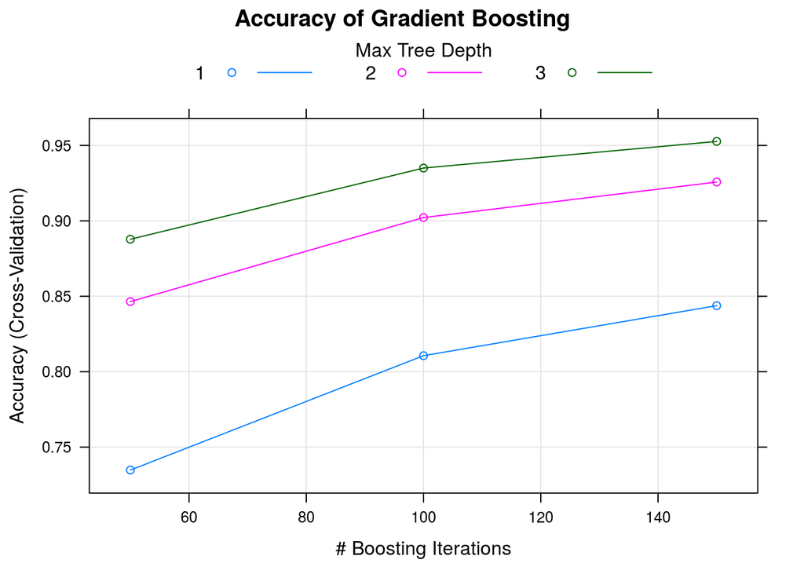

```r
# Plot your model_RF:
plot(model_GBM, main = "Accuracy of Gradient Boosting")
```

```r
# Predict using the model from trainNew on testNew & create the Confusion Matrix:
trainPred <- predict(model_GBM,newdata=testNew)
confMatGBM <- confusionMatrix(testNew$classe,trainPred)

# Display confusion matrix:
confMatGBM$table
```

```
##           Reference
## Prediction   A   B   C   D   E
##          A 822   9   4   1   1
##          B  16 528  18   2   5
##          C   0  13 496   4   0
##          D   2   1  16 456   7
##          E   1   7   9   9 515
```

```r
# Display model accuracy:
confMatGBM$overall[1]
```

```
##  Accuracy
## 0.9575119
```

The accuracy of the Gradient Boosting model is also high (~95%) using 5-fold cross-validation This implies that the outcome will be very well predicted by the predictors, but is still shy of the accuracy of the Random Forests model.

## Conclusion

Of the three models evaluated, notably Classification Trees, Random Forest and Gradient Boosting, the Random Forest model’s performance leads to the lowest error in prediction (and highest predictive ability with an accuracy of ~99%) using 5-fold cross-validation to prevent over-fitting. The Gradient Boosting model has the next lowest error with an accuracy of ~95%. Lastly, the Classification Trees has the weakest accuracy of three.